# Outlier Detection in Dow Jones using Support Vector Machines

Python

CS5805 23Fall

Machine Learning

Explore the application of SVM for anomaly detection in the Dow Jones data.

Published

November 16, 2023

#### **Intro**

In this project, we aim to apply the One-Class Support Vector Machine (SVM) algorithm for anomaly detection on the Dow Jones dataset from seaborn. The dataset comprises two columns: Date and Price, making it a suitable candidate for time-series anomaly detection. The One-Class SVM method is particularly effective for such tasks as it defines a boundary around normal data, and any data point falling outside this boundary is considered an anomaly. By leveraging this method, we hope to identify unusual patterns in the Dow Jones index that could potentially indicate significant financial events or market abnormalities. This approach could provide valuable insights for financial analysis and decision-making processes. Stay tuned as we dive into the details of implementing and optimizing the One-Class SVM model for our dataset.

#### **Necessary Packages**

```python
import numpy as np
import pandas as pd
import seaborn as sns
import matplotlib.pyplot as plt
from sklearn.preprocessing import MinMaxScaler, StandardScaler

plt.style.use('ggplot')
# print(f"List of seaborn datasets: \n{sns.get_dataset_names()}")
```

#### **Data Process**

##### **Download Data**

```python
dowjones_raw = sns.load_dataset('dowjones')
print(f"There are {dowjones_raw.isna().sum().sum()} missing values")
dowjones_raw
```

```
There are 0 missing values
```

|  | Date | Price |
| --- | --- | --- |
| 0 | 1914-12-01 | 55.00 |
| 1 | 1915-01-01 | 56.55 |
| 2 | 1915-02-01 | 56.00 |
| 3 | 1915-03-01 | 58.30 |
| 4 | 1915-04-01 | 66.45 |
| ... | ... | ... |
| 644 | 1968-08-01 | 883.72 |
| 645 | 1968-09-01 | 922.80 |
| 646 | 1968-10-01 | 955.47 |
| 647 | 1968-11-01 | 964.12 |
| 648 | 1968-12-01 | 965.39 |

649 rows × 2 columns

Next, we want to do some pre-process, although the dowjones dataset only contain 2 columns, we want to: - set the **Date** column to be the index

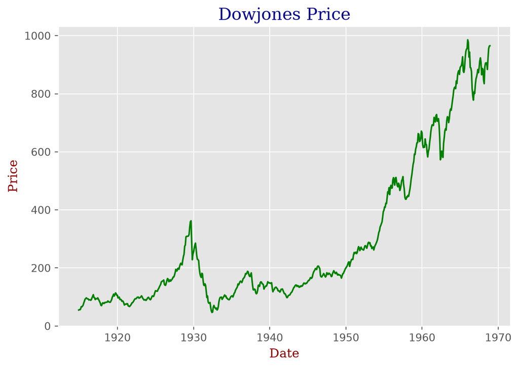

```python
dowjones = dowjones_raw.copy()
dowjones.set_index('Date', drop=True, inplace=True)

plt.figure()
plt.plot(dowjones, label="dowjones", c='g')
plt.xlabel('Date',  fontname='serif', color='darkred')
plt.ylabel('Price',  fontname='serif', color='darkred')
plt.title('Dowjones Price', fontname='serif', color='darkblue', fontsize=16)
plt.tight_layout()
plt.show()
```

- feature engineering on **Price**

```python
def minmax_scaler(window, value):
  return (value - window.min()) / (window.max() - window.min())

def zscore_scaler(window, value):
  z_score = (value - np.mean(window)) / (np.std(window))
  return z_score


def add_normalized_price(price, period):
    scaler = MinMaxScaler()
    price_normalized = pd.Series(index=price.index)
    half_period = np.round(period/2).astype(np.int16)

    for i, e in enumerate(price):
        start = max(0, i-half_period)
        end = min(price.shape[0], i+half_period)

        window = price.iloc[start:end]
        nromed_value = minmax_scaler(window, price.iloc[i])
        price_normalized.iloc[i] = nromed_value

    return price_normalized




price_norm = add_normalized_price(dowjones['Price'], 12)
dowjones['Normalized_Price'] = price_norm
dowjones
```

| Date | Price | Normalized_Price |
| --- | --- | --- |
| 1914-12-01 | 55.00 | 0.000000 |
| 1915-01-01 | 56.55 | 0.115672 |
| 1915-02-01 | 56.00 | 0.059347 |
| 1915-03-01 | 58.30 | 0.136082 |
| 1915-04-01 | 66.45 | 0.375410 |
| ... | ... | ... |
| 1968-08-01 | 883.72 | 0.374799 |
| 1968-09-01 | 922.80 | 0.673965 |
| 1968-10-01 | 955.47 | 0.878536 |
| 1968-11-01 | 964.12 | 0.984450 |
| 1968-12-01 | 965.39 | 1.000000 |

649 rows × 2 columns

Each price is normalized within a 12-month time frame, with the price ideally situated in the middle of this period. This approach aids in anomaly detection by identifying prices that are extreme for their specific time context, potentially signaling significant market events.

##### **Data Preview**

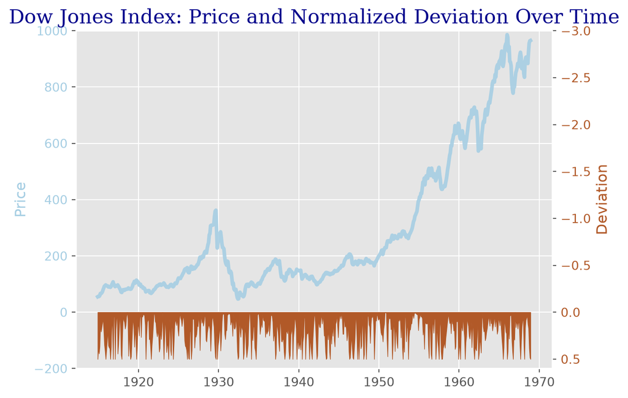

```python
colors=plt.get_cmap('Paired', 2)
fig, ax1 = plt.subplots()

ax1.plot(dowjones.index, dowjones.Price, color=colors(0), alpha=0.9, lw=3)
ax1.set_ylabel('Price', color=colors(0))
ax1.tick_params(axis='y', labelcolor=colors(0))
ax1.set_ylim(-200, 1000)

ax2 = ax1.twinx()
deviation = np.abs(dowjones.Normalized_Price-0.5)
ax2.fill_between(dowjones.index, 0, deviation, color=colors(1))
ax2.set_ylabel('Deviation', color=colors(1))
ax2.tick_params(axis='y', labelcolor=colors(1))
ax2.set_ylim(-3, 0.6)
ax2.grid()
ax2.invert_yaxis()

plt.title("Dow Jones Index: Price and Normalized Deviation Over Time", fontname='serif', color='darkblue', fontsize=16)
plt.show()
```

Try use IQR to detect outlier in dataset

```
Q1 and Q3 of Normalized_Price column is 0.32 & 0.70.
IQR is 0.38
Any value < -0.24 and  > 1.26 is an outlier.
There are 0 outliers.
```

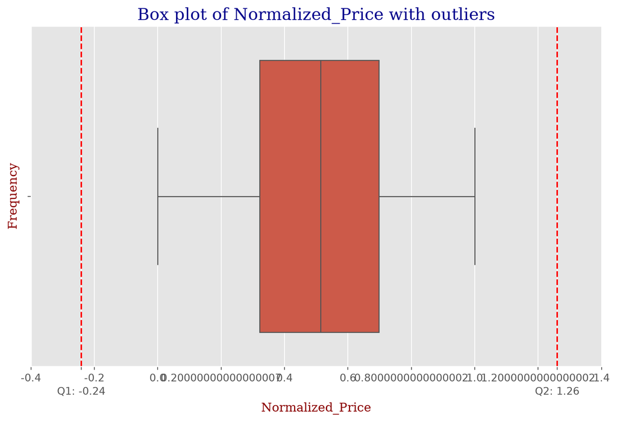

```python
# column_name = 'Price'
column_name = 'Normalized_Price'
q1 = dowjones[column_name].quantile(0.25)
q3 = dowjones[column_name].quantile(0.75)
iqr = q3 - q1

print(f"Q1 and Q3 of {column_name} column is {q1:.2f} & {q3:.2f}.\nIQR is {iqr:.2f}")

lower_bound = q1 - 1.5 * iqr
upper_bound = q3 + 1.5 * iqr
print(f"Any value < {lower_bound:.2f} and  > {upper_bound:.2f} is an outlier.")

outliers = dowjones[(dowjones[column_name] < lower_bound) | (dowjones[column_name] > upper_bound)]
print(f"There are {outliers.shape[0]} outliers.")


plt.figure(figsize=(10, 6))
sns.boxplot(x=dowjones[column_name])

plt.axvline(x=lower_bound, color='r', linestyle='--')
plt.axvline(x=upper_bound, color='r', linestyle='--')

ticks = list(plt.xticks()[0]) + [lower_bound] + [upper_bound]
labels = [str(t) for t in ticks]
labels[-2] = f'\nQ1: {lower_bound:.2f}'
labels[-1] = f'\nQ2: {upper_bound:.2f}'
plt.xticks(ticks, labels)

plt.xlabel(column_name, fontname='serif', color='darkred')
plt.ylabel('Frequency', fontname='serif', color='darkred')
plt.title(f'Box plot of {column_name} with outliers', fontname='serif', color='darkblue', fontsize=16)

# Show the plot
plt.show()
```

### **Support Vector Machine (SVM)**

- **Loss Function:** $\text{Loss} = \frac{1}{2} \sum_{i=1}^{n} w_i^2 - \rho$
- **Update Weights:** $w = w + \frac{\sum_{i=1}^{n} X_i}{n} - w$
- **Compute Rho:** $\rho = \text{percentile}(\text{distance}, \nu \times 100)$
- **Predict Function:**
  $$\text{{prediction}} =
  \begin{cases}
  1 & \text{{if }} x \cdot w \geq \rho \\
  -1 & \text{{otherwise}}
  \end{cases}$$

```python
def compute_loss(X, w, rho):
    return (1/2) * np.sum(w**2) - rho

def compute_rho(X, w, nu):
    dist = np.dot(X, w)
    return np.percentile(dist, nu * 100)

def update_weights(X, w, rho):
    dist = np.dot(X, w)
    outliers = dist < rho
    if np.any(outliers):
      w += np.sum(X[outliers], axis=0)/len(X[outliers]) - w
    else:
      w += np.random.normal(0, 1e-18, size=w.shape)

    return w

def fit(X, nu, max_iter, tol):
    n_samples, n_features = X.shape
    w = np.zeros(n_features)
    rho = np.min(X)

    for _ in range(max_iter):
        loss_old = compute_loss(X, w, rho)
        w = update_weights(X, w, rho)
        rho = compute_rho(X, w, nu)
        loss_new = compute_loss(X, w, rho)

        if np.abs(loss_new - loss_old) < tol:
            break

    return w, rho

def predict(X, w, rho):
    dist = np.dot(X, w)
    return np.where(dist >= rho, 1, 0)
```

fit the model

```python
column_name = 'Price'
X = dowjones[column_name].values.reshape(-1, 1)

nu = 0.05
max_iter = 1000
tol = 1e-3

w, rho = fit(X, nu, max_iter, tol)

predictions = predict(X, w, rho)
print(f"there is {X.shape[0] - predictions.sum()} outliers detected by column {column_name}")

outlier_indices = np.where(predictions == 0)[0]
outlier = dowjones.iloc[outlier_indices]
# outlier
```

```
there is 33 outliers detected by column Price
```

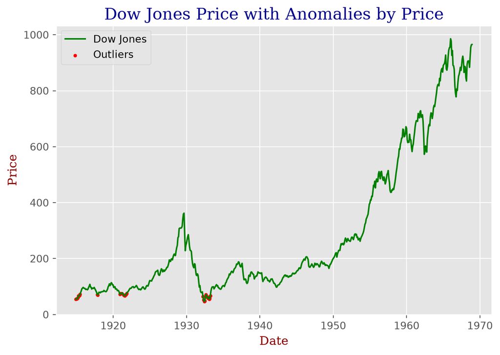

```python
plt.figure()
plt.plot(dowjones.Price, label="Dow Jones", c='g')
plt.scatter(outlier.index, outlier.Price, color='r', label='Outliers', s=10, marker='8')
plt.xlabel('Date',  fontname='serif', color='darkred')
plt.ylabel('Price',  fontname='serif', color='darkred')
plt.title(f'Dow Jones Price with Anomalies by {column_name}', fontname='serif', color='darkblue', fontsize=16)
plt.legend()
plt.tight_layout()
plt.show()
```

Without normalization, we can see the Anomalies are concentrated on a small period.

```python
column_name = 'Normalized_Price'
X = dowjones[column_name].values.reshape(-1, 1)

nu = 0.05
max_iter = 1000
tol = 1e-3

w, rho = fit(X, nu, max_iter, tol)

predictions = predict(X, w, rho)
print(f"there is {X.shape[0] - predictions.sum()} outliers detected by column {column_name}")

outlier_indices = np.where(predictions == 0)[0]
outlier = dowjones.iloc[outlier_indices]
# outlier
```

```
there is 33 outliers detected by column Normalized_Price
```

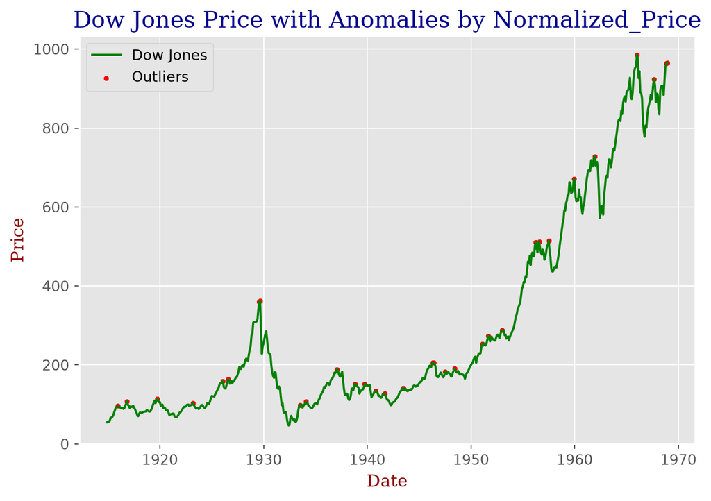

```python
plt.figure()
plt.plot(dowjones.Price, label="Dow Jones", c='g')
plt.scatter(outlier.index, outlier.Price, color='r', label='Outliers', s=10, marker='8')
plt.xlabel('Date',  fontname='serif', color='darkred')
plt.ylabel('Price',  fontname='serif', color='darkred')
plt.title(f'Dow Jones Price with Anomalies by {column_name}', fontname='serif', color='darkblue', fontsize=16)
plt.legend()
plt.tight_layout()
plt.show()
```

With normalization, we can see the Anomalies in each period. I think this provides more information on the performance of the stock market.

end.